# Homework 2

## 2) Following what we did in class show how to use the convolution operator to determine the probability of the sum of 2 six sided dice. Do both analytically (math & counting) and numerically (computer program). Beware the implicit definition of the values (x-axis on histogram)

The probability of the sum of 2 six sided dies can be best summed up with this equation p(x)=P(X=n)=1/36 * min(n−1,13−n). To get a sum of 1 - 0%, a roll of 2 - 1/36, a roll of 3 - 2/36, a roll of 4 3/36, a roll of 5 - 4/36, a roll of 6 - 5/36, a roll of 7 - 6/36, a roll of 8 - 5/36... all the way back down in increments of 1/36 down to a 0 percent chance to roll a 13.The convolution operator allows us to find the sum of the probabilities of two random variables by integrating the product of their probability density functions.

```python
%matplotlib inline
from random import seed
from random import gauss
import math
import numpy as np
import matplotlib
import matplotlib.pyplot as plt
from matplotlib.pyplot import figure
import scipy
import pylab
from scipy import stats
plt.rcParams["figure.figsize"] = (20,15)
```

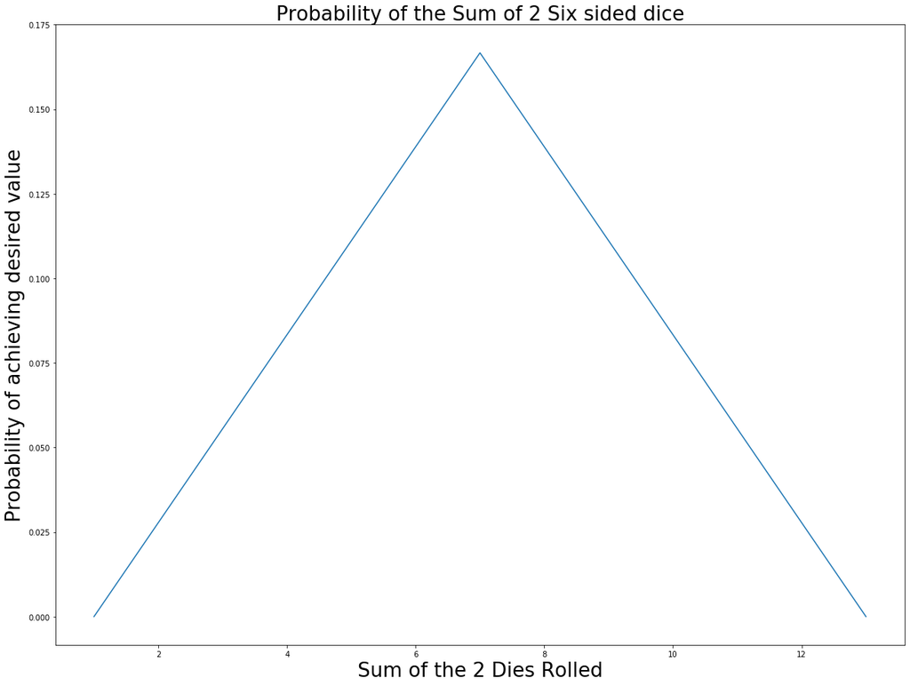

```python
x = np.linspace(1,13,13)
y = []
for i in x:
    val = (1/36) * min(i - 1, 13 - i)
    y.append(val)
plt.xlabel("Sum of the 2 Dies Rolled", fontsize = 26)
plt.ylabel("Probability of achieving desired value", fontsize = 26)
plt.title("Probability of the Sum of 2 Six sided dice", fontsize = 26)
plt.plot(x, y)
plt.show()
```

## 3) Calculate the mean and the variance of the distribution in problem 2. Hint: this is surprisingly tricky, make sure your result makes sense

```python
mean = np.mean(y)
print(mean * 100, "%")
variance = np.var(y)
print(variance)

print(np.std(y))
```

```
7.692307692307694 %
0.0027485572357367227
0.052426684386261954
```

## 4) Repeat 2, and graph the average of 10 dice. Is this is a Gaussian distribution? Explain in depth.

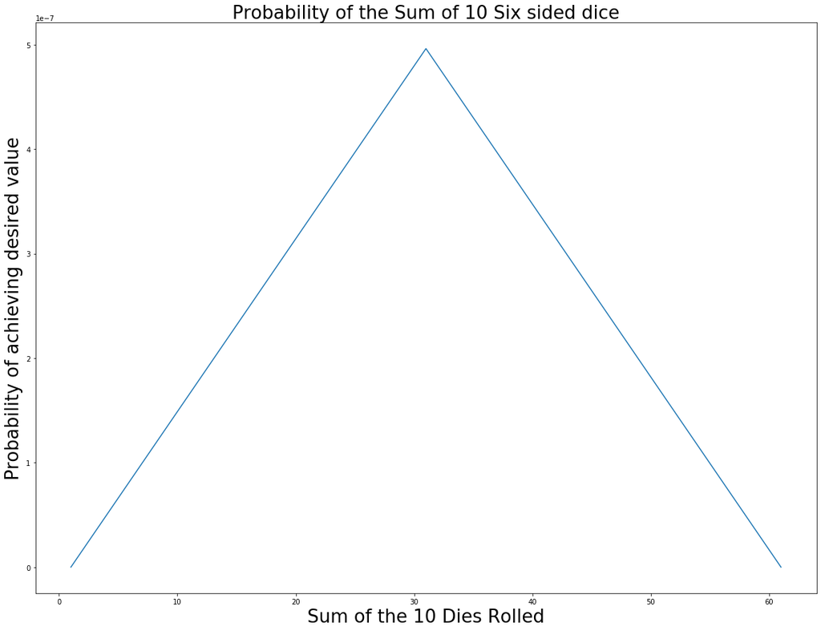

```
1.4565095903051894e-07
```

```python
x = np.linspace(1,61,61)
y = []
for i in x:
    val = (1/60466176) * min(i - 1, 61 - i)
    y.append(val)
plt.xlabel("Sum of the 10 Dies Rolled", fontsize = 26)
plt.ylabel("Probability of achieving desired value", fontsize = 26)
plt.title("Probability of the Sum of 10 Six sided dice", fontsize = 26)
plt.plot(x, y)
plt.show()

print(np.std(y))
```

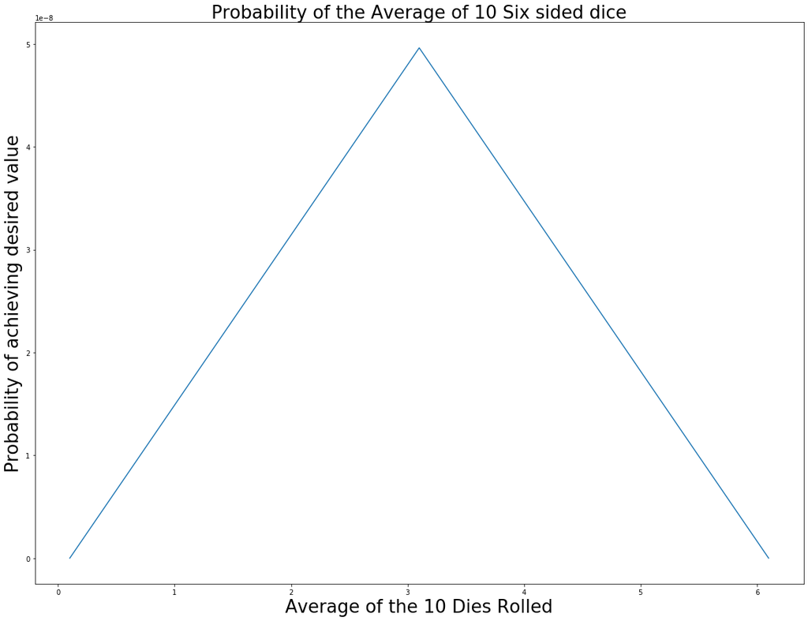

```
1.4565095903051892e-08
```

```python
x = np.linspace(1,61,61)
y = []
for i in x:
    val = (1/60466176) * min(i - 1, 61 - i)
    y.append(val)
x = np.divide(x,10)
y = np.divide(y,10)
plt.xlabel("Average of the 10 Dies Rolled", fontsize = 26)
plt.ylabel("Probability of achieving desired value", fontsize = 26)
plt.title("Probability of the Average of 10 Six sided dice", fontsize = 26)
plt.plot(x, y)
plt.show()

print(np.std(y))
```